# 데이터 과학 – 금융(Finance)

상장사 목록 → 주가

xwMOOC

Tidyverse Korea

2019-01-13

# 1 한국 거래종목 데이터

[한국거래소 KRX](http://www.krx.co.kr/)에서 `통계 &rarr; 주식 &rarr; 종목시세 &rarr; [81004] 전체 종목시세`에서 [81004 전체 종목시세](http://marketdata.krx.co.kr/mdi#document=13020101)에서 한국거래소에서 거래되고 있는 상장사 목록 및 시가총액 데이터를 구할 수 있다.

```r
library(tidyverse)
library(rvest)
library(readxl)
library(janitor)

kospi_dat <- read_excel("data/KRX-상장사-20190111.xlsx", sheet="KOSPI") %>%
  mutate(`거래소` = "코스피")
kosdaq_dat <- read_excel("data/KRX-상장사-20190111.xlsx", sheet="KOSDAQ") %>%
  mutate(`거래소` = "코스닥")

krx_dat <- bind_rows(kospi_dat,kosdaq_dat)  %>%
  set_names(c("종목코드", "종목명", "현재가", "대비", "등락률", "시가", "고가",
"저가", "거래량", "거래대금", "시가총액", "시총비중",
"상장주식수", "거래소")) %>%
  select_("거래소", "종목코드", "종목명", "현재가", "현재가",  "상장주식수", "시가총액")

krx_df <- krx_dat %>%
  mutate(`현재가` = parse_number(`현재가`),
          `상장주식수` = parse_number(`상장주식수`),
          `시가총액` = parse_number(`시가총액`)) %>%
  mutate(`시가총억원` = `시가총액`/1e8) %>%
  select(-`시가총액`)

krx_df %>%
  DT::datatable() %>%
  DT::formatRound(4:6, digits=0)
```

|  | 거래소 | 종목코드 | 종목명 | 현재가 | 상장주식수 | 시가총억원 |
| --- | --- | --- | --- | --- | --- | --- |
| 1 | 코스피 | 000020 | 동화약품 | 9400 | 27931470 | 2625.55818 |
| 2 | 코스피 | 000030 | 우리은행 | 14800 | 676000000 | 100048 |
| 3 | 코스피 | 000040 | KR모터스 | 538 | 189444075 | 1019.2091235 |
| 4 | 코스피 | 000050 | 경방 | 11300 | 27415270 | 3097.92551 |
| 5 | 코스피 | 000060 | 메리츠화재 | 22350 | 113680000 | 25407.48 |
| 6 | 코스피 | 000070 | 삼양홀딩스 | 82200 | 8564271 | 7039.830762 |
| 7 | 코스피 | 000075 | 삼양홀딩스우 | 46950 | 304058 | 142.755231 |
| 8 | 코스피 | 000080 | 하이트진로 | 16450 | 70133611 | 11536.9790095 |
| 9 | 코스피 | 000087 | 하이트진로2우B | 14200 | 1130138 | 160.479596 |
| 10 | 코스피 | 000100 | 유한양행 | 226000 | 12209354 | 27593.14004 |

[output cut: 2216 more lines]

우선주 시가총액 계산시 반영 검토.

```r
krx_df %>%
  filter(str_detect(`종목명`, "[0-9]?우[B]?$" ))
```

```
# A tibble: 118 x 6
   거래소 종목코드 종목명             현재가 상장주식수 시가총억원
   <chr>  <chr>    <chr>               <dbl>      <dbl>      <dbl>
 1 코스피 000075   삼양홀딩스우        46950     304058      143.
 2 코스피 000087   하이트진로2우B      14200    1130138      160.
 3 코스피 000105   유한양행우         207500     236188      490.
 4 코스피 000145   하이트진로홀딩스우   8110     470810       38.2
 5 코스피 000155   두산우              72800    4411074     3211.
 6 코스피 000157   두산2우B            73400     985685      723.
 7 코스피 000215   대림산업우          37200    3800000     1414.
 8 코스피 000225   유유제약1우          6900    1133465       78.2
 9 코스피 000227   유유제약2우B        17400     164080       28.5
10 코스피 000325   노루홀딩스우        17650     185250       32.7
# ... with 108 more rows
```

# 2 거래소 기초분석

## 2.1 거래소 규모

코스피와 코스닥에 따라 상장 기업수와 시가총액을 배교한다. “e-나라지표 국정모니터링지표”에서 [상장회사수, 시가총액](http://www.index.go.kr/potal/main/EachDtlPageDetail.do?idx_cd=1079)을 비교한다. e-나라지표에서 산출한 근거는 2018년 12월 31일 최종 거래 기준으로 이며 우선주가 해당회사에 귀속되어 차이가 난다.

- 유가증권시장: 788 社, 1,344 조
- 코스닥시장: 1,323 社, 228 조

```r
krx_df %>%
  count(`거래소`) %>%
  mutate(`비율` = scales::percent(n / sum(n)))
```

```
# A tibble: 2 x 3
  거래소     n 비율
  <chr>  <int> <chr>
1 코스닥  1325 59.5%
2 코스피   901 40.5%
```

```r
krx_df %>%
  group_by(`거래소`) %>%
  summarise(`시가총조원` = sum(`시가총억원`)/1e4) %>%
  mutate(`비율` = scales::percent(`시가총조원`/ sum(`시가총조원`)))
```

```
# A tibble: 2 x 3
  거래소 시가총조원 비율
  <chr>       <dbl> <chr>
1 코스닥       231. 14.5%
2 코스피      1368. 85.5%
```

## 2.2 거래소 상장사 시총비중

유가증권거래소와 코스닥을 합하면 약 2,000개 회사가 상장되어 있으며 상위 100개 회사 즉 5% 회사가 시가총액의 70%를 점유하고 있는 것이 확인된다.

```r
krx_top_df <- krx_df %>%
  arrange(desc(`시가총억원`)) %>%
  mutate(`누적시총_조` = cumsum(`시가총억원`)/1e4) %>%
  mutate(`누적시총_조_누적율` = `누적시총_조` / (sum(`시가총억원`)/1e4))

krx_top_df %>%
  top_n(100, wt=`시가총억원`) %>%
  DT::datatable() %>%
    DT::formatRound(c("현재가", "상장주식수", "시가총억원", "누적시총_조"), digits=0) %>%
    DT::formatPercentage("누적시총_조_누적율", digits=1)
```

|  | 거래소 | 종목코드 | 종목명 | 현재가 | 상장주식수 | 시가총억원 | 누적시총_조 | 누적시총_조_누적율 |
| --- | --- | --- | --- | --- | --- | --- | --- | --- |
| 1 | 코스피 | 005930 | 삼성전자 | 40500 | 5969782550 | 2417761.93275 | 241.776193275 | 0.151140200849951 |
| 2 | 코스피 | 000660 | SK하이닉스 | 65100 | 728002365 | 473929.539615 | 289.1691472365 | 0.180766693365971 |
| 3 | 코스피 | 005935 | 삼성전자우 | 33100 | 822886700 | 272375.4977 | 316.4066970065 | 0.197793550672041 |
| 4 | 코스피 | 068270 | 셀트리온 | 216500 | 125456133 | 271612.527945 | 343.567949801 | 0.214772712876104 |
| 5 | 코스피 | 005380 | 현대차 | 123000 | 213668187 | 262811.87001 | 369.849136802 | 0.23120172446778 |
| 6 | 코스피 | 207940 | 삼성바이오로직스 | 395500 | 66165000 | 261682.575 | 396.017394302 | 0.247560141071455 |
| 7 | 코스피 | 051910 | LG화학 | 349000 | 70592343 | 246367.27707 | 420.654122009 | 0.262961161012597 |
| 8 | 코스피 | 005490 | POSCO | 255500 | 87186835 | 222762.363425 | 442.9303583515 | 0.276886580175586 |
| 9 | 코스피 | 015760 | 한국전력 | 34700 | 641964077 | 222761.534719 | 465.2065118234 | 0.290811947534141 |
| 10 | 코스피 | 035420 | NAVER | 131000 | 164813395 | 215905.54745 | 486.7970665684 | 0.304308730391126 |

[output cut: 90 more lines]

## 2.3 거래소 시가총액

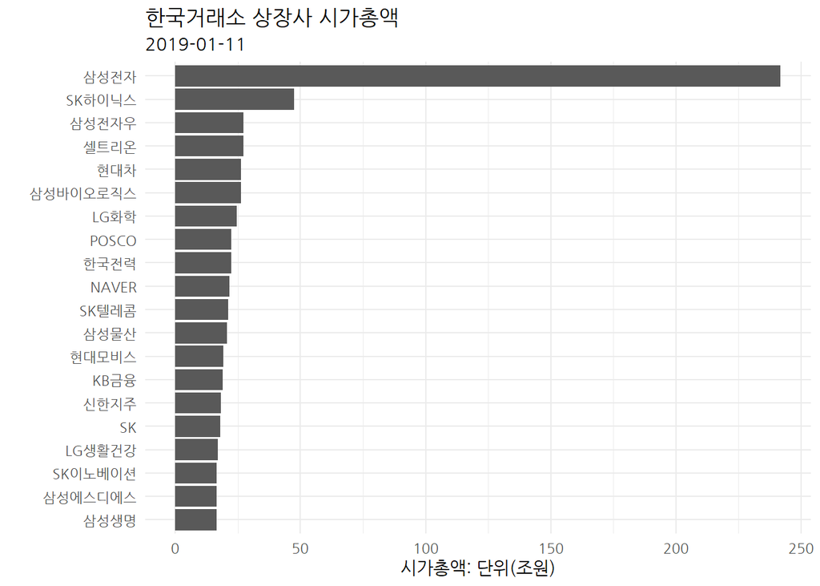

```r
library(extrafont)
loadfonts()

krx_top_df %>%
  slice(1:20) %>%
  mutate(`시총조원` = `시가총억원`/1e4) %>%
  ggplot(aes(x=fct_reorder(`종목명`,`시총조원`), y=`시총조원`)) +
    geom_col() +
    coord_flip() +
    labs(x="", y="시가총액: 단위(조원)", title="한국거래소 상장사 시가총액",
         subtitle = "2019-01-11") +
    theme_minimal(base_family = "NanumGothic")
```

# 3 주식 데이터

[`quantmod`](https://github.com/joshuaulrich/quantmod) 팩키지로부터 관심있는 주식에 대한 주식 종명명 약칭(stock symbol)을 찾아 바로 거래가격을 확인할 수 있다.

## 3.1 `quantmod` 헬로월드

`quantmod` 팩키지를 통해 주식 거래 데이터를 가져올 수 있다. 구글 금융(Google finance)은 2018년 3월 이후 서비스를 중단(`Google Finance stopped providing data in March, 2018.`)해서 대안으로 야후 금융(yahoo finance)에서 데이터를 가져온다.

야후 금융(Yahoo Finance)에서 거래주식 데이터를 가져오는 방식은 `종목코드.KS` 방식으로 하면 된다. 즉, 삼성전자(`005930`) 코드에 `.KS`를 붙이게 되면 `005930.KS`가 되고 이를 `quantmod` 팩키지 `getSymbols()` 함수에 넣어 주식거래 시세를 받아오면 된다.

`quantmod` 팩키지 시계열 데이터는 `OHLC` (Open, Hi, Lo and Close)를 담고 있기 때문에 다음 두가지 방식으로 데이터를 가져와서 분석에 사용할 수 있다.

```r
# remotes::install_github("joshuaulrich/quantmod")
library(quantmod)

`삼성전자` <- getSymbols("005930.KS", src = "yahoo", from = as.Date("2018-01-01"), to = Sys.Date(), auto.assign = FALSE)

head(`삼성전자`)
```

```
           005930.KS.Open 005930.KS.High 005930.KS.Low 005930.KS.Close
2018-01-02          51380          51400         50780           51020
2018-01-03          52540          52560         51420           51620
2018-01-04          52120          52180         50640           51080
2018-01-05          51300          52120         51200           52120
2018-01-08          52400          52520         51500           52020
2018-01-09          51460          51720         49980           50400
           005930.KS.Volume 005930.KS.Adjusted
2018-01-02          8474250           31996.27
2018-01-03         10013500           32372.55
2018-01-04         11695450           32033.90
2018-01-05          9481150           32686.12
2018-01-08          8383650           32623.40
2018-01-09         18013600           31607.45
```

```r
head(Cl(`삼성전자`))
```

```
           005930.KS.Close
2018-01-02           51020
2018-01-03           51620
2018-01-04           51080
2018-01-05           52120
2018-01-08           52020
2018-01-09           50400
```

## 3.2 한국상장 중국기업

[국내 상장 중국기업](http://www.infostock.co.kr/sector/code.asp?code=228)을 기사에서 뽑아 시가총액과 주식가격을 살펴보자.

### 3.2.1 국내상장 중국기업

상장사 시가총액이 담긴 데이터프레임과 결합하여 중국기업 상장주식수와 시가총액을 확인한다.

```r
library(extrafont)
loadfonts()

china_df <- tribble( ~ "종목코드", ~"종목명",
                       "900080", "에스앤씨엔진그룹",
                       "900040", "차이나그레이트",
                       "900110",    "이스트아시아홀딩스",
                       "900120", "씨케이에이치",
                       "900070", "글로벌에스엠",
                       "900250", "크리스탈신소재",
                       "900260", "로스웰",
                       "900270", "헝셩그룹",
                       "900280", "골든센츄리",
                       "900290", "GRT",
                       "900300", "오가닉티코스메틱",
                       "900310", "컬러레이")

china_df <- left_join(china_df, krx_df)

china_df %>%
  DT::datatable() %>%
    DT::formatRound(c("현재가", "상장주식수", "시가총억원"), digits=0)
```

|  | 종목코드 | 종목명 | 거래소 | 현재가 | 상장주식수 | 시가총억원 |
| --- | --- | --- | --- | --- | --- | --- |
| 1 | 900080 | 에스앤씨엔진그룹 | 코스닥 | 560 | 115239670 | 645.342152 |
| 2 | 900040 | 차이나그레이트 | 코스닥 | 313 | 125866557 | 393.96232341 |
| 3 | 900110 | 이스트아시아홀딩스 | 코스닥 | 244 | 109000686 | 265.96167384 |
| 4 | 900120 | 씨케이에이치 | 코스닥 | 326 | 110404457 | 359.91852982 |
| 5 | 900070 | 글로벌에스엠 | 코스닥 | 810 | 53743968 | 435.3261408 |
| 6 | 900250 | 크리스탈신소재 | 코스닥 | 1095 | 67783852 | 742.2331794 |
| 7 | 900260 | 로스웰 | 코스닥 | 1045 | 90781250 | 948.6640625 |
| 8 | 900270 | 헝셩그룹 | 코스닥 | 1130 | 80000000 | 904 |
| 9 | 900280 | 골든센츄리 | 코스닥 | 833 | 93400000 | 778.022 |
| 10 | 900290 | GRT | 코스닥 | 1900 | 67375000 | 1280.125 |

[output cut: 2 more lines]

### 3.2.2 주식거래 데이터

`quandmod` 팩키지 야후 금융 API를 통해 시세 데이터를 가져온다. 코스피는 `.KS`를 붙였다면, 코스닥은 `.KQ`를 붙이는 것이 차이점이 있다.

```r
china_stock_code <- paste0(china_df$`종목코드`, ".KQ")

getSymbols(china_stock_code, src = "yahoo", from = as.Date("2017-01-01"), to = Sys.Date(), auto.assign = TRUE)
```

```
 [1] "900080.KQ" "900040.KQ" "900110.KQ" "900120.KQ" "900070.KQ"
 [6] "900250.KQ" "900260.KQ" "900270.KQ" "900280.KQ" "900290.KQ"
[11] "900300.KQ" "900310.KQ"
```

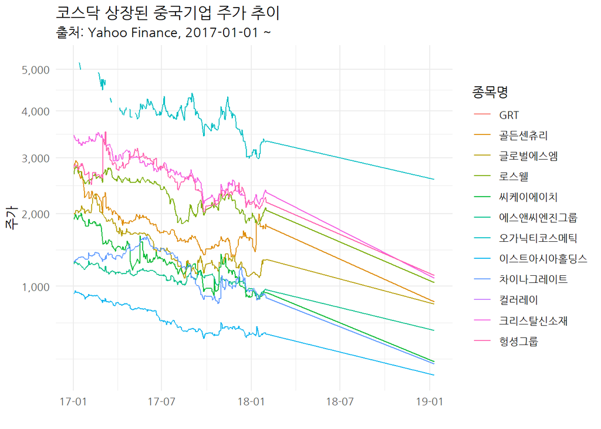

```r
# 제외
china_stock_zoo <- merge(`900080.KQ`, `900040.KQ`, `900110.KQ`, `900120.KQ`,`900070.KQ`, `900250.KQ`, `900260.KQ`, `900270.KQ`, `900280.KQ`,  `900300.KQ`, `900310.KQ`, `900290.KQ`)

china_stock_df <- data.frame(date=index(china_stock_zoo), coredata(china_stock_zoo))

china_stock_df %>%
  select(date, contains("Close")) %>%
  gather(`종목코드`, `주가`, -date) %>%
  mutate(`종목코드` = str_remove(`종목코드`, ".Close")) %>%
  mutate(`종목코드` = str_extract_all(`종목코드`, "\\d.+") %>% str_remove(.,".KQ")) %>%
  left_join(krx_df) %>%
  ggplot(aes(x=date, y=`주가`, color=`종목명`)) +
    geom_line() +
    scale_y_sqrt(labels = scales::comma) +
    scale_x_date(date_labels = "%y-%m") +
    labs(x="", y="주가", title="코스닥 상장된 중국기업 주가 추이",
         subtitle="출처: Yahoo Finance, 2017-01-01 ~") +
    theme_minimal(base_family = "NanumGothic")
```